# Отчёт по лабораторной работе №11

Настройка безопасного удалённого доступа по протоколу SSH

Бызова Мария Олеговна

2025-11-10

# Цель работы

## Цель работы

Приобретение практических навыков по настройке удалённого доступа к серверу с помощью SSH.

# Выполнение лабораторной работы

## Запрет удалённого доступа по SSH для пользователя root

На сервере задали пароль для пользователя root (рис. 1).

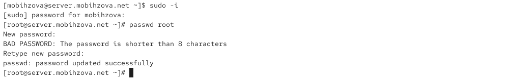

Рисунок 1: Установка пароля для пользователя root

## Запрет удалённого доступа по SSH для пользователя root

На сервере в дополнительном терминале запустили мониторинг системных событий (рис. 2).

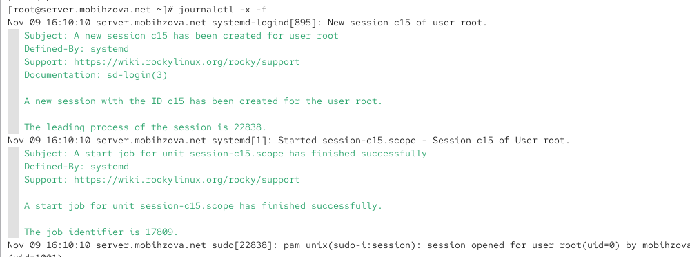

Рисунок 2: Запуск мониторинга системных событий

## Запрет удалённого доступа по SSH для пользователя root

С клиента попытались получить доступ к серверу посредством SSH-соединения через пользователя root (рис. 3).

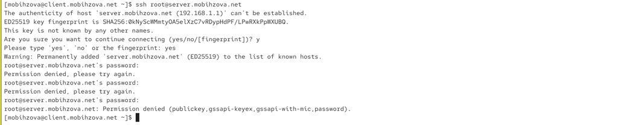

Рисунок 3: Попытка подключения под пользователем root

## Запрет удалённого доступа по SSH для пользователя root

После сохранения изменений в файле конфигурации перезапустили sshd (рис. 5).

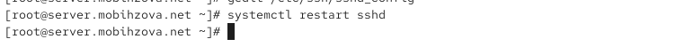

Рисунок 5: Перезапуск службы sshd

## Запрет удалённого доступа по SSH для пользователя root

Повторили попытку получения доступа с клиента к серверу посредством SSH-соединения через пользователя root (рис. 6).

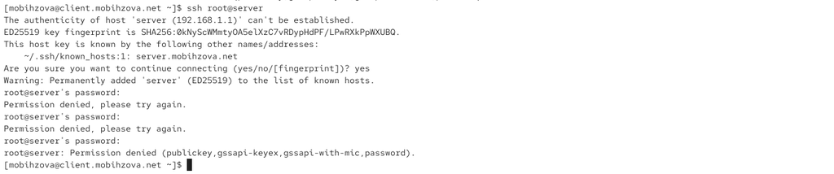

Рисунок 6: Повторная попытка подключения под root после настройки

## Ограничение списка пользователей для удалённого доступа по SSH

С клиента попытались получить доступ к серверу посредством SSH-соединения через пользователя mobihzova (рис. 7).

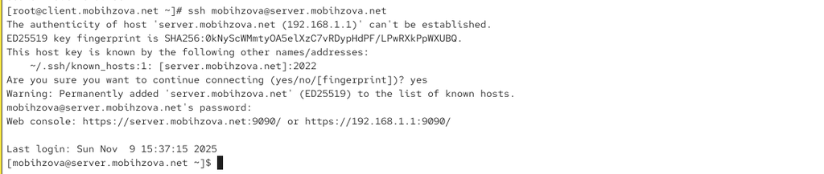

Рисунок 7: Подключение под пользователем mobihzova

## Ограничение списка пользователей для удалённого доступа по SSH

На сервере открыли файл /etc/ssh/sshd_config конфигурации sshd на редактирование и добавили строку AllowUsers vagrant (рис. 8).

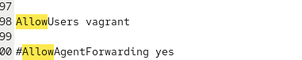

Рисунок 8: Добавление AllowUsers vagrant

## Ограничение списка пользователей для удалённого доступа по SSH

Повторили попытку получения доступа с клиента к серверу посредством SSH-соединения через пользователя mobihzova (рис. 10).

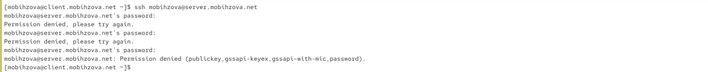

Рисунок 10: Попытка подключения после ограничения пользователей

## Ограничение списка пользователей для удалённого доступа по SSH

В файле /etc/ssh/sshd_config конфигурации sshd внесли следующее изменение: AllowUsers vagrant mobihzova (рис. 11).

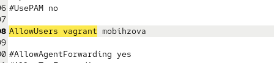

Рисунок 11: Добавление пользователя mobihzova в AllowUsers

## Ограничение списка пользователей для удалённого доступа по SSH

После сохранения изменений в файле конфигурации перезапустили sshd (рис. 12).

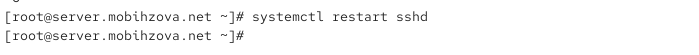

Рисунок 12: Перезапуск sshd после добавления пользователя

## Ограничение списка пользователей для удалённого доступа по SSH

Повторно попытались получить доступ с клиента к серверу посредством SSH-соединения через пользователя mobihzova (рис. 13).

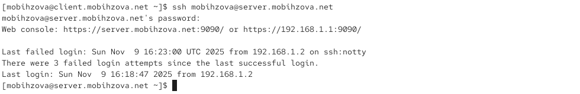

Рисунок 13: Успешное подключение после добавления в AllowUsers

## Настройка дополнительных портов для удалённого доступа по SSH

На сервере в файле конфигурации sshd /etc/ssh/sshd_config нашли строку Port и ниже этой строки добавили: Port 22, Port 2022 (рис. 14).

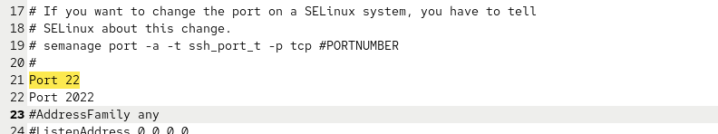

Рисунок 14: Добавление порта 2022 в конфигурацию

## Настройка дополнительных портов для удалённого доступа по SSH

После сохранения изменений в файле конфигурации перезапустили sshd (рис. 15).

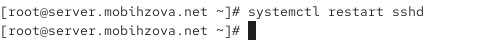

Рисунок 15: Перезапуск sshd с новым портом

## Настройка дополнительных портов для удалённого доступа по SSH

Посмотрели расширенный статус работы sshd (рис. 16).

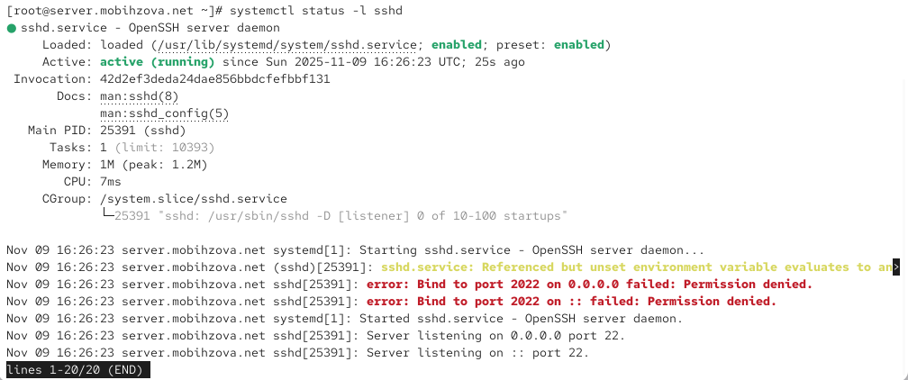

Рисунок 16: Статус sshd после добавления порта

## Настройка дополнительных портов для удалённого доступа по SSH

В терминале с мониторингом системных событий наблюдали сообщения об ошибках (рис. 17).

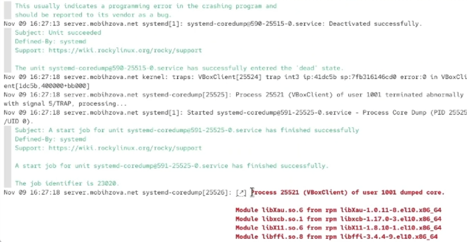

Рисунок 17: Сообщения об ошибках в journalctl

## Настройка дополнительных портов для удалённого доступа по SSH

Исправили на сервере метки SELinux к порту 2022 (рис. 18).

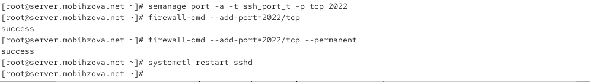

Рисунок 18: Настройка SELinux для порта 2022

## Настройка дополнительных портов для удалённого доступа по SSH

В настройках межсетевого экрана открыли порт 2022 протокола TCP. Вновь перезапустили sshd и посмотрели расширенный статус его работы (рис. 19).

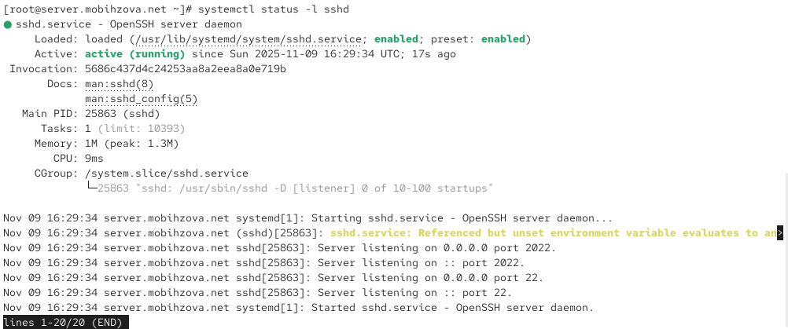

Рисунок 19: Статус sshd после настройки SELinux и фаервола

## Настройка дополнительных портов для удалённого доступа по SSH

С клиента попытались получить доступ к серверу посредством SSH-соединения через пользователя mobihzova (рис. 20).

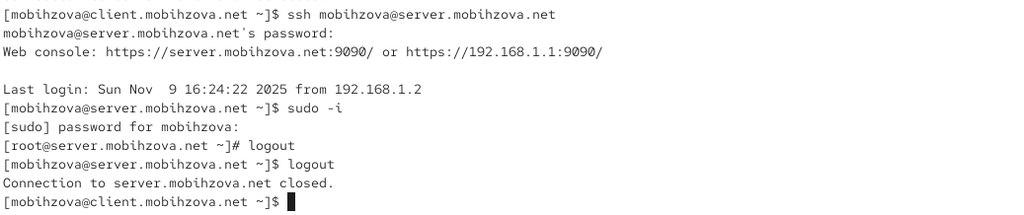

Рисунок 20: Подключение через стандартный порт

## Настройка дополнительных портов для удалённого доступа по SSH

Повторили попытку получения доступа с клиента к серверу посредством SSH-соединения через пользователя mobihzova, указав порт 2022 (рис. 21).

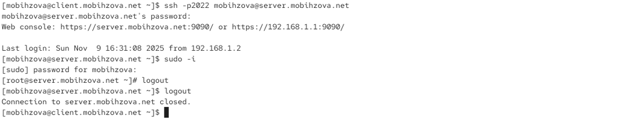

Рисунок 21: Подключение через порт 2022

## Настройка удалённого доступа по SSH по ключу

На сервере в конфигурационном файле /etc/ssh/sshd_config задали параметр, разрешающий аутентификацию по ключу: PubkeyAuthentication yes (рис. 22).

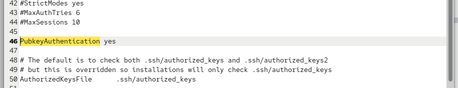

Рисунок 22: Включение аутентификации по ключу

## Настройка удалённого доступа по SSH по ключу

После сохранения изменений в файле конфигурации перезапустили sshd (рис. 23).

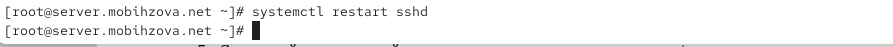

Рисунок 23: Перезапуск sshd после настройки ключей

## Настройка удалённого доступа по SSH по ключу

На клиенте сформировали SSH-ключ, введя в терминале под пользователем mobihzova: ssh-keygen (рис. 24).

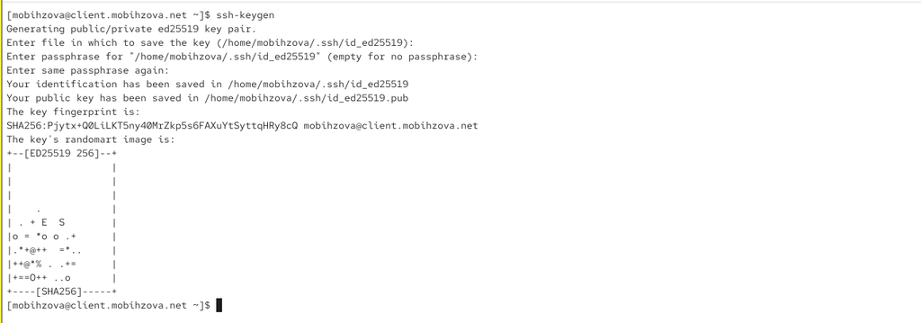

Рисунок 24: Генерация SSH-ключа на клиенте

## Настройка удалённого доступа по SSH по ключу

Скопировали открытый ключ на сервер, введя на клиенте: ssh-copy-id mobihzova@server.mobihzova.net (рис. 25).

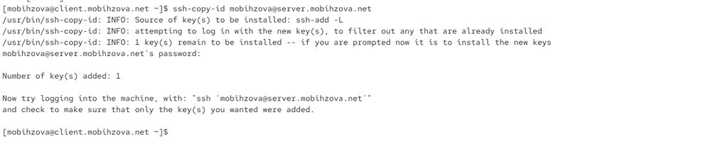

Рисунок 25: Копирование публичного ключа на сервер

## Настройка удалённого доступа по SSH по ключу

Попробовали получить доступ с клиента к серверу посредством SSH-соединения (рис. 26).

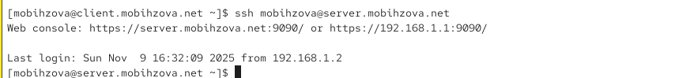

Рисунок 26: Подключение по SSH-ключу без пароля

## Организация туннелей SSH, перенаправление TCP-портов

На клиенте посмотрели, запущены ли какие-то службы с протоколом TCP (рис. 27).

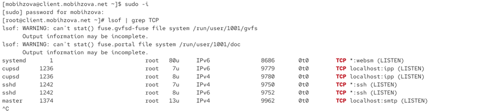

Рисунок 27: Проверка TCP-соединений до туннеля

## Организация туннелей SSH, перенаправление TCP-портов

Перенаправили порт 80 на server.mobihzova.net на порт 8080 на локальной машине (рис. 28).

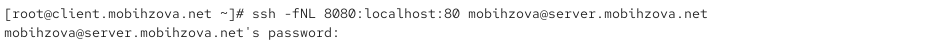

Рисунок 28: Создание SSH-туннеля

## Организация туннелей SSH, перенаправление TCP-портов

Вновь на клиенте посмотрели, запущены ли какие-то службы с протоколом TCP (рис. 29).

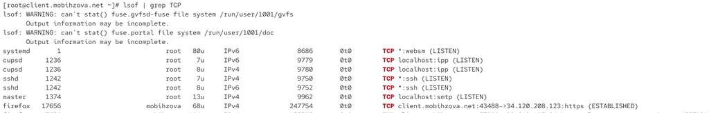

Рисунок 29: Проверка TCP-соединений после туннеля

## Организация туннелей SSH, перенаправление TCP-портов

На клиенте запустили браузер и в адресной строке ввели localhost:8080 (рис. 30).

[figure not shown]

Рисунок 30: Доступ к веб-серверу через туннель

## Запуск консольных приложений через SSH

На клиенте открыли терминал под пользователем mobihzova. Посмотрели с клиента имя узла сервера (рис. 31).

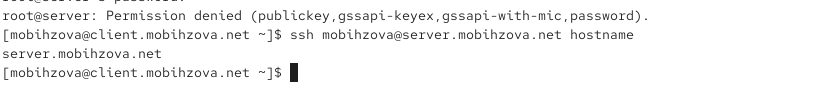

Рисунок 31: Удалённое выполнение команды hostname

## Запуск консольных приложений через SSH

Посмотрели с клиента список файлов на сервере (рис. 32).

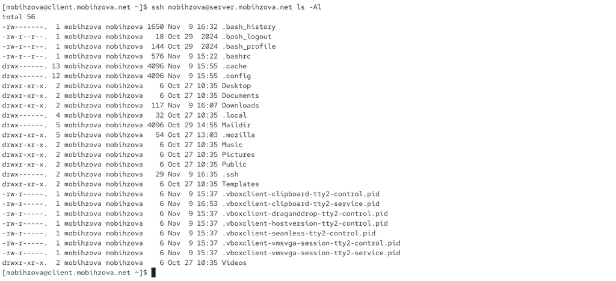

Рисунок 32: Удалённое выполнение команды ls